# Effects of the Credit Rating to the Loan Status

## by Terhi Takala

### The main interest in the dataset

The main interest in this exploration was to find features that could help to predict the outcome if the loan will become default or if it will be completed succesfully.

### What is the structure of your dataset?

There are 30 columns and 113937 rows in the dataset, and after removing duplicate rows and missing values the final data consisted of 95406 listings.

## Distribution of Loan Status

Around 71% of the loans are completed and 29% are defaulted in the data.

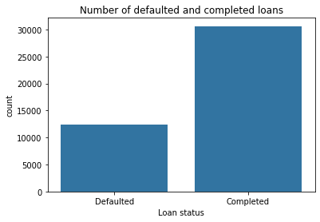

```python
# Plotting the loan statuses in df_grouped
loan_statuses = ['Defaulted', 'Completed']

base_color = sns.color_palette()[0]
ax = sns.countplot(data = df_grouped, x = 'LoanStatus', color = base_color)
ax.set_xticklabels(loan_statuses)
plt.title('Number of defaulted and completed loans')
plt.xlabel('Loan status');
```

### Distribution of Credit Rating

There are 7 different levels in the credit rating, AA being the best and HR being the worst. The ratings in the plot are ordered from best (on the left) to the worst (on the right).

The greatest number of borrowers in the data have credit ratings D and C, around 9000 and 7500 respectively. The best credit rating group AA is the smallest with only a bit above 4000 borrowers.

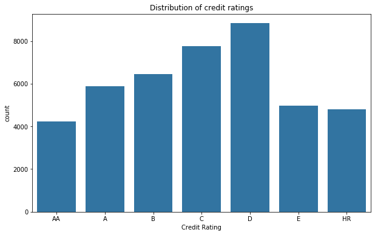

```python
# Plotting the categorical variable ratingCombined with countplot
plt.figure(figsize = [10, 6])
ax = sns.countplot(data = df_grouped, x = 'RatingCombined', color = base_color);
ax.set_title('Distribution of credit ratings')
ax.set_xlabel('Credit Rating');
```

## Loan Status vs. Credit Rating

Plotting the credit rating and loan status in a an adapted bar chart, we can clearly see that there is a relationship between the credit rating and the loan status. Loans with the worst credit rating HR are failing 44% of the time, while loans with good credit rating AA only fail 11% of the time. We can say that the credit score that Prosper is using is very efficient in predicting the outcome of the loan.

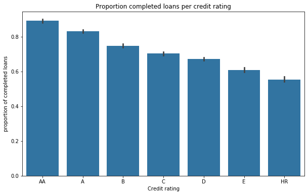

```python
# Creating a barplot against RatingCombined and loanStatus
plt.figure(figsize = [10, 6])
ax = sns.barplot(data = df_grouped, x = 'RatingCombined', y='LoanStatus', color = base_color)
ax.set_xlabel('Credit rating')
ax.set_ylabel('proportion of completed loans')
ax.set_title('Proportion completed loans per credit rating');
```

## Loan Status and Interest Rate by Credit Rating

There is interaction effect visible between Loan status, borrower interest rate and the credit rating: AA, A, B, C, D, E and HR. The defaulted loans have higher interest rates and borrower interest rates increase as the credit ratings get worse.

The defaulted loans have higher interest rates especially in the higher credit ratings. For example borrowers with credit rating AA whose loans were defaulted, had average interest rates at 12%, while in comparison completed loans have average interest rate at around 9%.

The difference between the interest rates become less obvious between credit ratings D, E and HR, and in fact, borrowers with credit rating HR and whose loans were completed, had a bit higher range of interest rates compared to defaulted loans.

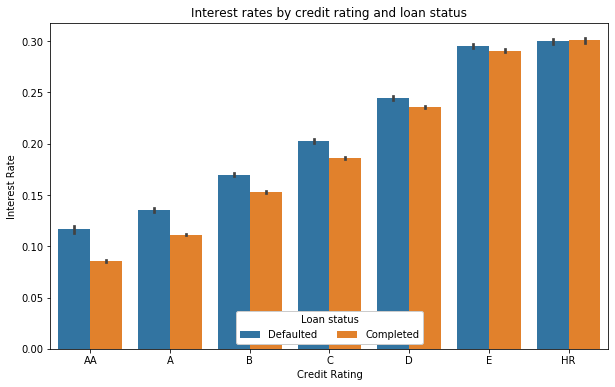

```python
# plotting the interest rate against credit rating and loan status
plt.figure(figsize = [10, 6])
ax = sns.barplot(data = df_grouped, x = 'RatingCombined', y = 'BorrowerRate', hue = 'LoanStatus')
ax.legend(loc = 8, ncol = 7, framealpha = 1)
ax.set_title('Interest rates by credit rating and loan status')
ax.set_xlabel('Credit Rating')
ax.set_ylabel('Interest Rate')

leg = ax.axes.get_legend()
new_title = 'Loan status'
leg.set_title(new_title)
new_labels = ['Defaulted', 'Completed']
for t, l in zip(leg.texts, new_labels): t.set_text(l);
```